# WET Psychoeducation

## Some Background

When we feel anxious or distressed, our natural response is to avoid the thing that triggers our negative feelings. For instance, when faced with a venomous snake, it is natural and important to immediately move away from it. However, we also tend to avoid thoughts and images: we don’t like imagining the things that scare us, although the thoughts themselves are not dangerous at all. Studies show that avoidance is exactly what maintains their power over us.

There are many reasons for this. Among others, if we always avoid imagining frightening and unpleasant things, how can we truly know that our imagination is not dangerous? Or that we are capable of tolerating it?

To process your anxiety and distress, we’ll do an exercise that involves imagining the things you’re afraid of “all-in,” without trying to avoid them. This helps you process them deeply, enabling you to step back from the anxiety and view it in a more reasonable perspective, so that the fear does not control you.

### Example and Metaphor

This might seem very difficult and even counterintuitive. Many people try hard to avoid imagining the things that trigger their negative emotions, and you are now asked to take a 180-degree turn and deliberately think about the least comfortable things. Why would you agree to do that? Others feel that they are already imagining frightening or distressing scenarios all the time, so why would going even further in that direction help?

To understand the purpose of this exercise, let us use a metaphor. Imagine watching a horror film. How would you feel the first time watching it? Scared, right? But what about the third time? It might be a little less scary, right?

And the tenth time? And the hundredth time?

Eventually, it just becomes plain boring.

This is what we are trying to achieve by using repetitive imagination in this exercise. In the same way that the movie ceases to be scary after watching it enough times, your personal “horror film” will gradually cease to affect you.

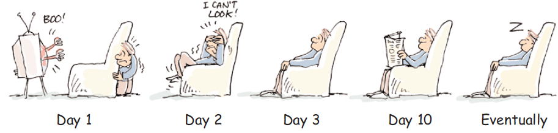

Horror Movie

This is what we aim to achieve by engaging in this exercise: to desensitize your fear through repeated imagination, reducing its emotional intensity over time.

### Reflection Questions

How anxious do you expect to be if you deeply imagine the realization of your core threat once?

1. Not at all anxious (1)
2. Slightly anxious (2)
3. Moderately anxious (3)
4. Quite anxious (4)
5. Extremely anxious (5)

How anxious do you expect to be if you deeply imagine the realization of your core threat for 20 straight minutes? 1. Not at all anxious (1)  
2. Slightly anxious (2)  
3. Moderately anxious (3)  
4. Quite anxious (4)  
5. Extremely anxious (5)

## Writing Exercise: Important!

The purpose of this exercise is to help you fully experience and process your distress about the future event by writing about it in intense detail. Do not focus on grammar or spelling. Write about your anxiety exactly the way you fear it to be. Attempt to write as vividly as possible to express the full richness of the experience.

### Writing Guidelines

- Use **present tense** and **first-person perspective** to simulate your involvement in the situation.
- Describe:
  - **Details of the event**: What happens? What are the key moments?
  - **Sensory experiences**: What do you see, hear, smell, touch?
  - **Thoughts and feelings**: What are you thinking and feeling in the moment?
  - **Bodily sensations**: For example, “I can feel a choking sensation in my throat, my stomach is turning, and I feel nauseous.”

If you get stuck, try closing your eyes and imagining yourself in the threatening situation. Pay attention to the sensations and feelings that come up, and start describing them in your text. At any point, you can ask yourself: “What is the worst thing that could happen at this point?”

If you feel like you’re done writing, start over from the beginning and try to enrich and extend your story.

**Important:** As you write, you may notice an increase in your anxiety and distress levels. This is completely normal and expected – it means you are confronting the things that trouble you. This is your chance to process and better understand your fear.

## Writing About Your Experience

Your writing exercise will be timed for 20 minutes. Make sure that you are sitting in a quiet place and that you are available to concentrate for 20 minutes straight. Now, take a moment to think about what you would like to write. Hold a specific instance in your mind so that you can experience it in full detail.

When writing, you can choose to write in an organized manner or in a stream of consciousness. If you feel like you’re done with writing, go back to the beginning and write again until time runs out. Your task is to write continuously during the whole 20 minutes.

When you are ready, press “Continue” to begin the timer.

## Writing Focus

**Please take 20 minutes to write about it.** If you finish writing before the time is up, start over. Your task is to write continuously for the entire 20 minutes.

When writing, make sure you refer to the following three stages:

1. **Take a Risk**: Imagine doing something you would generally choose to avoid.
2. **Suffer Consequences**: Describe what you fear might happen.
3. **Catastrophe**: Provide detailed descriptions of how your core threat comes to be.

**Here are some principles of writing to keep in mind:**

- Use **present tense**.
- Write in **first-person perspective**.
- Include **sensory experiences** such as sound, color, and scent.
- Describe your **thoughts and feelings**.
- **Keep writing without stopping** – let whatever comes to mind flow onto the page.